# AMR Project MCA Analysis

## Sex

### Mechanism

```r
formula <- ~factor(sex)
ps.use <- ps.mechanism.filtered
caption <- "Table 47: POLR Model of Mechanism-Level Abundance by Sex, No Covariates"
outfile <- "sex_no_covs_MECHANISM.txt"
###
fit.polr(formula, ps.use, caption, outfile)
```

Table 47: POLR Model of Mechanism-Level Abundance by Sex, No Covariates

| Output is in the file sex_no_covs_MECHANISM.txt ID | Output is in the file sex_no_covs_MECHANISM.txt Coefficient | Output is in the file sex_no_covs_MECHANISM.txt P.Value | Output is in the file sex_no_covs_MECHANISM.txt adj.P.Val | Output is in the file sex_no_covs_MECHANISM.txt Class | Output is in the file sex_no_covs_MECHANISM.txt Mechanism | Output is in the file sex_no_covs_MECHANISM.txt Group | Output is in the file sex_no_covs_MECHANISM.txt Gene |
| --- | --- | --- | --- | --- | --- | --- | --- |
| MEG_4160 | 0.8847137 | 0.0052937 | 0.1852789 | Metals | Chromium_resistance | NA | NA |
| MEG_2873 | 0.6680535 | 0.0160959 | 0.2816789 | Biocides | Phenolic_compound_resistance | NA | NA |
| MEG_4170 | 0.5854757 | 0.0297403 | 0.3469706 | Metals | Nickel_resistance | NA | NA |
| MEG_3244 | 0.5165712 | 0.0610244 | 0.3632995 | Drugs | Aminocoumarins | NA | NA |
| MEG_7841 | 0.4306857 | 0.0704518 | 0.3632995 | Multi-compound | Biocide_and_metal_resistance | NA | NA |
| MEG_1189 | 0.5818983 | 0.0887680 | 0.3632995 | Drugs | Bacitracin | NA | NA |
| MEG_3291 | 0.5423204 | 0.0979633 | 0.3632995 | Biocides | Acetate_resistance | NA | NA |
| MEG_3295 | -0.3366320 | 0.1022059 | 0.3632995 | Drugs | Mupirocin | NA | NA |
| MEG_2952 | 0.4059857 | 0.1273799 | 0.3632995 | Drugs | Sulfonamides | NA | NA |
| MEG_4162 | 0.4746524 | 0.1285084 | 0.3632995 | Metals | Sodium_resistance | NA | NA |
| MEG_2578 | 0.3053096 | 0.1357392 | 0.3632995 | Drugs | Trimethoprim | NA | NA |
| MEG_7862 | 0.3811277 | 0.1524480 | 0.3632995 | Metals | Zinc_resistance | NA | NA |
| MEG_7811 | 0.5110034 | 0.1550362 | 0.3632995 | Metals | Iron_resistance | NA | NA |
| MEG_2443 | 0.3379275 | 0.1598858 | 0.3632995 | Metals | Copper_resistance | NA | NA |
| MEG_1488 | 0.2775374 | 0.1762683 | 0.3632995 | Metals | Multi-metal_resistance | NA | NA |
| MEG_1229 | 0.2756974 | 0.1776980 | 0.3632995 | Multi-compound | Drug_and_biocide_resistance | NA | NA |
| MEG_6093 | -0.2723481 | 0.1828963 | 0.3632995 | Drugs | Rifampin | NA | NA |
| MEG_3287 | 0.3308619 | 0.1984920 | 0.3632995 | Biocides | Peroxide_resistance | NA | NA |
| MEG_3271 | 0.3011964 | 0.1985167 | 0.3632995 | Drugs | Multi-drug_resistance | NA | NA |
| MEG_2701 | 0.3088328 | 0.2171474 | 0.3632995 | Biocides | Acid_resistance | NA | NA |
| MEG_6551 | 0.3308503 | 0.2179797 | 0.3632995 | Multi-compound | Drug_and_biocide_and_metal_resistance | NA | NA |
| MEG_3 | -0.2390931 | 0.2429471 | 0.3760319 | Drugs | Aminoglycosides | NA | NA |
| MEG_5814 | 0.2977258 | 0.2471067 | 0.3760319 | Metals | Arsenic_resistance | NA | NA |
| MEG_7318 | -0.1995061 | 0.3302670 | 0.4573586 | Drugs | Elfamycins | NA | NA |
| MEG_1576 | -0.1984118 | 0.3344375 | 0.4573586 | Drugs | Phenicol | NA | NA |
| MEG_6166 | 0.1996997 | 0.3397521 | 0.4573586 | Drugs | Nucleosides | NA | NA |
| MEG_3988 | 0.1714354 | 0.4022398 | 0.5214220 | Drugs | MLS | NA | NA |
| MEG_6138 | 0.1616235 | 0.4318730 | 0.5398412 | Drugs | Glycopeptides | NA | NA |
| MEG_5321 | 0.1891313 | 0.4521442 | 0.5456913 | Biocides | Multi-biocide_resistance | NA | NA |
| MEG_3219 | -0.1522617 | 0.5136357 | 0.5992417 | Drugs | Fluoroquinolones | NA | NA |
| MEG_4223 | -0.0923557 | 0.6515475 | 0.7011421 | Drugs | Oxazolidinone | NA | NA |
| MEG_7330 | 0.1198459 | 0.6557116 | 0.7011421 | Drugs | Fosfomycin | NA | NA |
| MEG_1490 | 0.0906378 | 0.6610768 | 0.7011421 | Drugs | Cationic_antimicrobial_peptides | NA | NA |
| MEG_6964 | 0.0797265 | 0.6966074 | 0.7170959 | Drugs | Tetracyclines | NA | NA |
| MEG_1695 | 0.0638517 | 0.7550910 | 0.7550910 | Drugs | betalactams | NA | NA |

### Gene

```r
formula <- ~factor(sex)
ps.use <- ps.gene.filtered
caption <- "Table 48: POLR Model of Gene-Level Abundance by Sex, No Covariates"
outfile <- "sex_no_covs_GENE.txt"
###
fit.polr(formula, ps.use, caption, outfile)
```

Table 48: POLR Model of Gene-Level Abundance by Sex, No Covariates

| Output is in the file sex_no_covs_GENE.txt ID | Output is in the file sex_no_covs_GENE.txt Coefficient | Output is in the file sex_no_covs_GENE.txt P.Value | Output is in the file sex_no_covs_GENE.txt adj.P.Val | Output is in the file sex_no_covs_GENE.txt Class | Output is in the file sex_no_covs_GENE.txt Mechanism | Output is in the file sex_no_covs_GENE.txt Group | Output is in the file sex_no_covs_GENE.txt Gene |
| --- | --- | --- | --- | --- | --- | --- | --- |
| MEG_2725 | 1.1225882 | 0.0050741 | 0.2111400 | Multi-compound | Drug_and_biocide_resistance | Drug_and_biocide_MFS_efflux_pumps | EMRB |
| MEG_4160 | 0.8847137 | 0.0052937 | 0.2111400 | Metals | Chromium_resistance | Chromium_resistance_protein | NFSA |
| MEG_6970 | 0.5667706 | 0.0059060 | 0.2111400 | Drugs | Tetracyclines | Tetracycline_resistance_ribosomal_protection_proteins | TET32 |
| MEG_3083 | 0.8458302 | 0.0066432 | 0.2111400 | Multi-compound | Drug_and_biocide_resistance | Drug_and_biocide_RND_efflux_regulator | GADX |
| MEG_3663 | 0.8559051 | 0.0069978 | 0.2111400 | Multi-compound | Drug_and_biocide_resistance | Drug_and_biocide_RND_efflux_regulator | MARR |
| MEG_7477 | 0.8158694 | 0.0077271 | 0.2111400 | Drugs | Glycopeptides | VanD-type_regulator | VANRD |
| MEG_3662 | 0.9089628 | 0.0079290 | 0.2111400 | Multi-compound | Drug_and_biocide_resistance | Drug_and_biocide_RND_efflux_regulator | MARA |
| MEG_410 | 1.0031931 | 0.0100940 | 0.2111400 | Multi-compound | Drug_and_biocide_resistance | Drug_and_biocide_RND_efflux_pumps | ACRF |
| MEG_4103 | 0.9206784 | 0.0113124 | 0.2111400 | Multi-compound | Drug_and_biocide_resistance | Drug_and_biocide_SMR_efflux_pumps | MVRC |
| MEG_2092 | 0.9477243 | 0.0120310 | 0.2111400 | Metals | Multi-metal_resistance | Multi-metal_resistance_protein | CORD |
| MEG_2739 | 0.8988339 | 0.0141335 | 0.2111400 | Drugs | Cationic_antimicrobial_peptides | Lipid_A_modification | EPTA |
| MEG_7859 | 0.8896952 | 0.0151291 | 0.2111400 | Metals | Zinc_resistance | Zinc_resistance_protein | ZNUC |
| MEG_2899 | 0.8328290 | 0.0157795 | 0.2111400 | Multi-compound | Biocide_and_metal_resistance | Biocide_and_metal_ABC_efflux_pumps | FETB |
| MEG_3622 | 0.9502545 | 0.0157877 | 0.2111400 | Biocides | Acetate_resistance | Acetate_resistance_protein | LPDT |
| MEG_3998 | 0.8572077 | 0.0161265 | 0.2111400 | Metals | Multi-metal_resistance | Multi-metal_resistance_protein | MNTH |
| MEG_2875 | 0.7766746 | 0.0185075 | 0.2111400 | Biocides | Phenolic_compound_resistance | Phenolic_resistance_protein | FABI |
| MEG_7833 | 0.6871485 | 0.0193130 | 0.2111400 | Multi-compound | Biocide_and_metal_resistance | Biocide_and_metal_resistance_protein | YHCN |
| MEG_2454 | 0.7237161 | 0.0194184 | 0.2111400 | Metals | Copper_resistance | Copper_resistance_protein | CUTA |
| MEG_1193 | 0.9267603 | 0.0196650 | 0.2111400 | Multi-compound | Drug_and_biocide_and_metal_resistance | Drug_and_biocide_and_metal_RND_efflux_regulator | BAES |
| MEG_4167 | 0.7189902 | 0.0233573 | 0.2144616 | Metals | Nickel_resistance | Nickel_ABC_efflux_pumps | NIKA |
| MEG_7837 | 0.6917873 | 0.0237707 | 0.2144616 | Biocides | Multi-biocide_resistance | Multi-biocide_resistance_protein | YJCG |
| MEG_7849 | 0.7660908 | 0.0240053 | 0.2144616 | Metals | Multi-metal_resistance | Multi-metal_resistance_protein | ZINT |
| MEG_2088 | 0.7482693 | 0.0241795 | 0.2144616 | Metals | Multi-metal_resistance | Multi-metal_resistance_protein | CORB |
| MEG_1701 | 0.7583571 | 0.0264899 | 0.2251643 | Metals | Sodium_resistance | Sodium_resistance_protein | CHAA |
| MEG_2689 | 0.7614556 | 0.0296476 | 0.2419248 | Metals | Multi-metal_resistance | Multi-metal_resistance_protein | DSBB |
| MEG_4000 | 0.6810073 | 0.0328329 | 0.2510046 | Metals | Multi-metal_resistance | Multi-metal_resistance_protein | MNTR |
| MEG_7835 | 0.6668878 | 0.0332212 | 0.2510046 | Multi-compound | Biocide_and_metal_resistance | Biocide_and_metal_resistance_protein | YIEF |
| MEG_408 | 0.6403857 | 0.0409319 | 0.2734473 | Multi-compound | Drug_and_biocide_resistance | Drug_and_biocide_RND_efflux_pumps | ACRE |
| MEG_4002 | 0.6555660 | 0.0411418 | 0.2734473 | Metals | Multi-metal_resistance | Multi-metal_ABC_efflux_pumps | MODA |
| MEG_4177 | 0.6118414 | 0.0433893 | 0.2734473 | Metals | Nickel_resistance | Nickel_ABC_efflux_regulator | NIKR |

[output cut: 174 more lines]

## BMI

### Mechanism

```r
formula <- ~bmi_final
ps.use <- ps.mechanism.filtered
caption <- "Table 49: POLR Model of Mechanism-Level Abundance by BMI, No Covariates"
outfile <- "BMI_no_covs_MECHANISM.txt"
###
fit.polr(formula, ps.use, caption, outfile)
```

Table 49: POLR Model of Mechanism-Level Abundance by BMI, No Covariates

| Output is in the file BMI_no_covs_MECHANISM.txt ID | Output is in the file BMI_no_covs_MECHANISM.txt Coefficient | Output is in the file BMI_no_covs_MECHANISM.txt P.Value | Output is in the file BMI_no_covs_MECHANISM.txt adj.P.Val | Output is in the file BMI_no_covs_MECHANISM.txt Class | Output is in the file BMI_no_covs_MECHANISM.txt Mechanism | Output is in the file BMI_no_covs_MECHANISM.txt Group | Output is in the file BMI_no_covs_MECHANISM.txt Gene |
| --- | --- | --- | --- | --- | --- | --- | --- |
| MEG_7318 | -0.0608064 | 0.0031716 | 0.0982410 | Drugs | Elfamycins | NA | NA |
| MEG_5814 | -0.0723685 | 0.0084509 | 0.0982410 | Metals | Arsenic_resistance | NA | NA |
| MEG_3219 | -0.0636919 | 0.0102973 | 0.0982410 | Drugs | Fluoroquinolones | NA | NA |
| MEG_1576 | -0.0538754 | 0.0112275 | 0.0982410 | Drugs | Phenicol | NA | NA |
| MEG_7841 | -0.0601921 | 0.0170204 | 0.1191428 | Multi-compound | Biocide_and_metal_resistance | NA | NA |
| MEG_2701 | -0.0538952 | 0.0418174 | 0.2439350 | Biocides | Acid_resistance | NA | NA |
| MEG_2578 | 0.0385889 | 0.0668077 | 0.2764277 | Drugs | Trimethoprim | NA | NA |
| MEG_7330 | -0.0517662 | 0.0711408 | 0.2764277 | Drugs | Fosfomycin | NA | NA |
| MEG_6093 | -0.0364405 | 0.0847320 | 0.2764277 | Drugs | Rifampin | NA | NA |
| MEG_5321 | -0.0452960 | 0.0885864 | 0.2764277 | Biocides | Multi-biocide_resistance | NA | NA |
| MEG_1189 | -0.0607550 | 0.0948663 | 0.2764277 | Drugs | Bacitracin | NA | NA |
| MEG_1488 | -0.0346371 | 0.0976850 | 0.2764277 | Metals | Multi-metal_resistance | NA | NA |
| MEG_3287 | -0.0441572 | 0.1037065 | 0.2764277 | Biocides | Peroxide_resistance | NA | NA |
| MEG_2443 | -0.0405562 | 0.1106088 | 0.2764277 | Metals | Copper_resistance | NA | NA |
| MEG_6551 | -0.0439580 | 0.1184690 | 0.2764277 | Multi-compound | Drug_and_biocide_and_metal_resistance | NA | NA |
| MEG_4170 | -0.0418448 | 0.1336703 | 0.2804143 | Metals | Nickel_resistance | NA | NA |
| MEG_3271 | -0.0364763 | 0.1362012 | 0.2804143 | Drugs | Multi-drug_resistance | NA | NA |
| MEG_2873 | -0.0371462 | 0.1957889 | 0.3560898 | Biocides | Phenolic_compound_resistance | NA | NA |
| MEG_3 | -0.0272924 | 0.2010862 | 0.3560898 | Drugs | Aminoglycosides | NA | NA |
| MEG_1490 | -0.0263446 | 0.2085008 | 0.3560898 | Drugs | Cationic_antimicrobial_peptides | NA | NA |
| MEG_7811 | -0.0466393 | 0.2136539 | 0.3560898 | Metals | Iron_resistance | NA | NA |
| MEG_1229 | -0.0242186 | 0.2400194 | 0.3778988 | Multi-compound | Drug_and_biocide_resistance | NA | NA |
| MEG_7862 | -0.0313494 | 0.2545127 | 0.3778988 | Metals | Zinc_resistance | NA | NA |
| MEG_6138 | -0.0232878 | 0.2591306 | 0.3778988 | Drugs | Glycopeptides | NA | NA |
| MEG_3244 | -0.0302112 | 0.2817366 | 0.3944312 | Drugs | Aminocoumarins | NA | NA |
| MEG_6964 | -0.0195309 | 0.3389654 | 0.4562995 | Drugs | Tetracyclines | NA | NA |
| MEG_4162 | -0.0288647 | 0.3659413 | 0.4676142 | Metals | Sodium_resistance | NA | NA |
| MEG_3291 | -0.0301391 | 0.3740914 | 0.4676142 | Biocides | Acetate_resistance | NA | NA |
| MEG_4160 | -0.0218611 | 0.4861030 | 0.5866760 | Metals | Chromium_resistance | NA | NA |
| MEG_6166 | -0.0113149 | 0.5931422 | 0.6919993 | Drugs | Nucleosides | NA | NA |
| MEG_2952 | -0.0134634 | 0.6221196 | 0.7023931 | Drugs | Sulfonamides | NA | NA |
| MEG_3295 | -0.0088153 | 0.6781578 | 0.7417350 | Drugs | Mupirocin | NA | NA |
| MEG_4223 | 0.0051142 | 0.8037819 | 0.8524960 | Drugs | Oxazolidinone | NA | NA |
| MEG_3988 | -0.0043460 | 0.8380685 | 0.8627176 | Drugs | MLS | NA | NA |
| MEG_1695 | 0.0029536 | 0.8864549 | 0.8864549 | Drugs | betalactams | NA | NA |

### Gene

```r
formula <- ~bmi_final
ps.use <- ps.gene.filtered
caption <- "Table 50: POLR Model of Gene-Level Abundance by BMI, No Covariates"
outfile <- "BMI_no_covs_GENE.txt"
###
fit.polr(formula, ps.use, caption, outfile)
```

Table 50: POLR Model of Gene-Level Abundance by BMI, No Covariates

| Output is in the file BMI_no_covs_GENE.txt ID | Output is in the file BMI_no_covs_GENE.txt Coefficient | Output is in the file BMI_no_covs_GENE.txt P.Value | Output is in the file BMI_no_covs_GENE.txt adj.P.Val | Output is in the file BMI_no_covs_GENE.txt Class | Output is in the file BMI_no_covs_GENE.txt Mechanism | Output is in the file BMI_no_covs_GENE.txt Group | Output is in the file BMI_no_covs_GENE.txt Gene |
| --- | --- | --- | --- | --- | --- | --- | --- |
| MEG_7318 | -0.0608064 | 0.0031716 | 0.5554371 | Drugs | Elfamycins | EF-Tu_inhibition | TUFAB |
| MEG_2132 | -0.0801832 | 0.0074180 | 0.5554371 | Multi-compound | Drug_and_biocide_resistance | Drug_and_biocide_RND_efflux_regulator | CRP |
| MEG_6048 | -0.0892331 | 0.0108891 | 0.5554371 | Metals | Multi-metal_resistance | Multi-metal_resistance_protein | RCNA |
| MEG_2115 | -0.0797179 | 0.0108909 | 0.5554371 | Multi-compound | Drug_and_biocide_resistance | Drug_and_biocide_RND_efflux_regulator | CPXAR |
| MEG_3219 | -0.0623458 | 0.0150950 | 0.5575914 | Drugs | Fluoroquinolones | Fluoroquinolone-resistant_DNA_topoisomerases | GYRA |
| MEG_5814 | -0.0670028 | 0.0200579 | 0.5575914 | Metals | Arsenic_resistance | Arsenic_resistance_protein | PSTB |
| MEG_4167 | -0.0713066 | 0.0334403 | 0.5575914 | Metals | Nickel_resistance | Nickel_ABC_efflux_pumps | NIKA |
| MEG_6970 | -0.0442090 | 0.0360738 | 0.5575914 | Drugs | Tetracyclines | Tetracycline_resistance_ribosomal_protection_proteins | TET32 |
| MEG_7330 | -0.0639967 | 0.0430732 | 0.5575914 | Drugs | Fosfomycin | Fosfomycin_target_mutation | UHPT |
| MEG_7150 | -0.0428561 | 0.0441100 | 0.5575914 | Drugs | Tetracyclines | Tetracycline_resistance_ribosomal_protection_proteins | TETO |
| MEG_3751 | -0.0673163 | 0.0442529 | 0.5575914 | Multi-compound | Drug_and_biocide_resistance | Drug_and_biocide_RND_efflux_pumps | MDTE |
| MEG_6138 | -0.0428311 | 0.0457641 | 0.5575914 | Drugs | Glycopeptides | Vancomycin-resistant_mutation | RPOC |
| MEG_4012 | -0.0683443 | 0.0478772 | 0.5575914 | Metals | Multi-metal_resistance | Multi-metal_ABC_efflux_pumps | MODC |
| MEG_3253 | -0.0629986 | 0.0537821 | 0.5575914 | Biocides | Acid_resistance | Acid_resistance_protein | HDEA |
| MEG_1636 | 0.0398448 | 0.0545989 | 0.5575914 | Drugs | betalactams | Class_A_betalactamases | CBLA |
| MEG_7813 | -0.0573330 | 0.0598682 | 0.5575914 | Multi-compound | Biocide_and_metal_resistance | Biocide_and_metal_resistance_protein | YCHH |
| MEG_2734 | -0.0608288 | 0.0599211 | 0.5575914 | Multi-compound | Drug_and_biocide_resistance | Drug_and_biocide_MFS_efflux_regulator | EMRR |
| MEG_7867 | -0.0678905 | 0.0607292 | 0.5575914 | Metals | Zinc_resistance | Zinc_resistance_regulator | ZUR |
| MEG_2867 | -0.0676174 | 0.0627245 | 0.5575914 | Biocides | Acid_resistance | Acid_resistance_regulator | EVGA |
| MEG_6146 | -0.0389325 | 0.0666751 | 0.5575914 | Drugs | Aminoglycosides | Aminoglycoside-resistant_16S_ribosomal_subunit_protein | RRSC |
| MEG_2578 | 0.0385889 | 0.0668077 | 0.5575914 | Drugs | Trimethoprim | Dihydrofolate_reductase | DFRF |
| MEG_7833 | -0.0568922 | 0.0672198 | 0.5575914 | Multi-compound | Biocide_and_metal_resistance | Biocide_and_metal_resistance_protein | YHCN |
| MEG_2451 | -0.0586285 | 0.0675321 | 0.5575914 | Metals | Multi-metal_resistance | Multi-metal_RND_efflux_pumps | CUSF |
| MEG_3144 | -0.0636705 | 0.0707329 | 0.5575914 | Drugs | Fosfomycin | Fosfomycin_target_mutation | GLPT |
| MEG_3287 | -0.0535203 | 0.0755224 | 0.5575914 | Biocides | Peroxide_resistance | Peroxide_resistance_stress_protein | IBPA |
| MEG_6656 | -0.0616401 | 0.0763197 | 0.5575914 | Multi-compound | Biocide_and_metal_resistance | Biocide_and_metal_resistance_protein | TEHB |
| MEG_7055 | -0.0495928 | 0.0814832 | 0.5575914 | Drugs | Tetracyclines | Tetracycline_resistance_MFS_efflux_pumps | TETBP |
| MEG_2801 | -0.0365249 | 0.0825359 | 0.5575914 | Drugs | MLS | 23S_rRNA_methyltransferases | ERMB |
| MEG_7842 | -0.0611373 | 0.0830272 | 0.5575914 | Multi-compound | Drug_and_biocide_resistance | Drug_and_biocide_ABC_efflux_pumps | YOGI |
| MEG_399 | -0.0526129 | 0.0831873 | 0.5575914 | Multi-compound | Drug_and_biocide_resistance | Drug_and_biocide_RND_efflux_pumps | ACRA |

[output cut: 174 more lines]

## Ethnicity

### Mechanism

```r
formula <- ~Ethnicity
ps.use <- ps.mechanism.filtered
caption <- "Table 51: POLR Model of Mechanism-Level Abundance by Ethnicity, No Covariates"
outfile <- "Ethnicity_no_covs_MECHANISM.txt"
###
fit.polr(formula, ps.use, caption, outfile)
```

Table 51: POLR Model of Mechanism-Level Abundance by Ethnicity, No Covariates

| Output is in the file Ethnicity_no_covs_MECHANISM.txt ID | Output is in the file Ethnicity_no_covs_MECHANISM.txt Coefficient | Output is in the file Ethnicity_no_covs_MECHANISM.txt P.Value | Output is in the file Ethnicity_no_covs_MECHANISM.txt adj.P.Val | Output is in the file Ethnicity_no_covs_MECHANISM.txt Class | Output is in the file Ethnicity_no_covs_MECHANISM.txt Mechanism | Output is in the file Ethnicity_no_covs_MECHANISM.txt Group | Output is in the file Ethnicity_no_covs_MECHANISM.txt Gene |
| --- | --- | --- | --- | --- | --- | --- | --- |
| MEG_6093 | 0.5124942 | 0.0007811 | 0.0185072 | Drugs | Rifampin | NA | NA |
| MEG_3295 | 0.1583086 | 0.0010576 | 0.0185072 | Drugs | Mupirocin | NA | NA |
| MEG_6138 | -0.1353318 | 0.0075039 | 0.0875452 | Drugs | Glycopeptides | NA | NA |
| MEG_3988 | 0.9193388 | 0.0341757 | 0.2835464 | Drugs | MLS | NA | NA |
| MEG_1695 | -0.5224790 | 0.0405066 | 0.2835464 | Drugs | betalactams | NA | NA |
| MEG_6964 | 1.4382386 | 0.0761695 | 0.4373078 | Drugs | Tetracyclines | NA | NA |
| MEG_3271 | -0.0667491 | 0.0874616 | 0.4373078 | Drugs | Multi-drug_resistance | NA | NA |
| MEG_7862 | -0.7417773 | 0.1184292 | 0.4975015 | Metals | Zinc_resistance | NA | NA |
| MEG_4223 | 0.5512316 | 0.1379484 | 0.4975015 | Drugs | Oxazolidinone | NA | NA |
| MEG_1576 | 0.6296798 | 0.1507658 | 0.4975015 | Drugs | Phenicol | NA | NA |
| MEG_7811 | 15.1253036 | 0.1563576 | 0.4975015 | Metals | Iron_resistance | NA | NA |
| MEG_7841 | -0.1705332 | 0.1897208 | 0.5533522 | Multi-compound | Biocide_and_metal_resistance | NA | NA |
| MEG_6551 | -0.5689679 | 0.2377164 | 0.5944707 | Multi-compound | Drug_and_biocide_and_metal_resistance | NA | NA |
| MEG_2578 | 1.0276756 | 0.2529926 | 0.5944707 | Drugs | Trimethoprim | NA | NA |
| MEG_4170 | -0.8409284 | 0.2547732 | 0.5944707 | Metals | Nickel_resistance | NA | NA |
| MEG_4162 | -0.6881466 | 0.3230328 | 0.6691808 | Metals | Sodium_resistance | NA | NA |
| MEG_7330 | -0.3583288 | 0.3690579 | 0.6691808 | Drugs | Fosfomycin | NA | NA |
| MEG_3287 | -0.8898796 | 0.3969145 | 0.6691808 | Biocides | Peroxide_resistance | NA | NA |
| MEG_2701 | -0.4577149 | 0.4221349 | 0.6691808 | Biocides | Acid_resistance | NA | NA |
| MEG_5814 | 0.0821630 | 0.4364301 | 0.6691808 | Metals | Arsenic_resistance | NA | NA |
| MEG_1488 | -0.0768080 | 0.4466442 | 0.6691808 | Metals | Multi-metal_resistance | NA | NA |
| MEG_6166 | -0.8491761 | 0.4634904 | 0.6691808 | Drugs | Nucleosides | NA | NA |
| MEG_5321 | -0.4613978 | 0.4741507 | 0.6691808 | Biocides | Multi-biocide_resistance | NA | NA |
| MEG_3 | 0.9395636 | 0.4955379 | 0.6691808 | Drugs | Aminoglycosides | NA | NA |
| MEG_2443 | -0.1225833 | 0.5062386 | 0.6691808 | Metals | Copper_resistance | NA | NA |
| MEG_3291 | -0.7045760 | 0.5255699 | 0.6691808 | Biocides | Acetate_resistance | NA | NA |
| MEG_7318 | -0.2758118 | 0.5519511 | 0.6691808 | Drugs | Elfamycins | NA | NA |
| MEG_1189 | 0.7342043 | 0.5533255 | 0.6691808 | Drugs | Bacitracin | NA | NA |
| MEG_1490 | -0.1683207 | 0.5544641 | 0.6691808 | Drugs | Cationic_antimicrobial_peptides | NA | NA |
| MEG_3219 | 0.0609339 | 0.6415902 | 0.7485219 | Drugs | Fluoroquinolones | NA | NA |
| MEG_4160 | -0.5484667 | 0.6927371 | 0.7783412 | Metals | Chromium_resistance | NA | NA |
| MEG_3244 | -0.2246721 | 0.7116263 | 0.7783412 | Drugs | Aminocoumarins | NA | NA |
| MEG_1229 | 0.1296556 | 0.7785535 | 0.8257386 | Multi-compound | Drug_and_biocide_resistance | NA | NA |
| MEG_2873 | -0.2712585 | 0.8338950 | 0.8584213 | Biocides | Phenolic_compound_resistance | NA | NA |
| MEG_2952 | 0.3992586 | 0.8788967 | 0.8788967 | Drugs | Sulfonamides | NA | NA |

P-value reported above is for global test for ethnicity, do some post-hoc testing:

```r
x <- "MEG_6093"
df <- as.data.frame(unclass(sample_data(ps.mechanism.filtered)))
df$y <- as.numeric(otu_table(ps.mechanism.filtered)[x,])
mod <- polr(factor(y) ~ Ethnicity, data = df, Hess = T)
pairs(emmeans(mod, ~Ethnicity))
```

```
## Note: Use 'contrast(regrid(object), ...)' to obtain contrasts of back-transformed estimates
```

```
##  contrast                     estimate    SE  df z.ratio p.value
##  African.American - Asian      -0.5125 0.613 Inf -0.836  0.9609
##  African.American - Caucasian   0.5276 0.539 Inf  0.979  0.9247
##  African.American - Hispanic    0.5649 0.595 Inf  0.950  0.9333
##  African.American - Multi      -1.1279 0.681 Inf -1.657  0.5606
##  African.American - Other       0.3796 0.846 Inf  0.449  0.9977
##  Asian - Caucasian              1.0401 0.349 Inf  2.982  0.0341
##  Asian - Hispanic               1.0774 0.430 Inf  2.507  0.1220
##  Asian - Multi                 -0.6154 0.540 Inf -1.140  0.8646
##  Asian - Other                  0.8921 0.739 Inf  1.207  0.8336
##  Caucasian - Hispanic           0.0373 0.309 Inf  0.121  1.0000
##  Caucasian - Multi             -1.6555 0.459 Inf -3.603  0.0043
##  Caucasian - Other             -0.1479 0.677 Inf -0.218  0.9999
##  Hispanic - Multi              -1.6928 0.524 Inf -3.233  0.0155
##  Hispanic - Other              -0.1852 0.722 Inf -0.256  0.9999
##  Multi - Other                  1.5076 0.797 Inf  1.892  0.4073
##
## Note: contrasts are still on the factor scale
## P value adjustment: tukey method for comparing a family of 6 estimates
```

```r
x <- "MEG_3295"
df <- as.data.frame(unclass(sample_data(ps.mechanism.filtered)))
df$y <- as.numeric(otu_table(ps.mechanism.filtered)[x,])
mod <- polr(factor(y) ~ Ethnicity, data = df, Hess = T)
pairs(emmeans(mod, ~Ethnicity))
```

```
## Note: Use 'contrast(regrid(object), ...)' to obtain contrasts of back-transformed estimates
```

```
##  contrast                     estimate    SE  df z.ratio p.value
##  African.American - Asian      -0.1583 0.605 Inf -0.262  0.9998
##  African.American - Caucasian   0.7386 0.539 Inf  1.370  0.7450
##  African.American - Hispanic    0.6379 0.597 Inf  1.069  0.8937
##  African.American - Multi      -0.9921 0.680 Inf -1.460  0.6901
##  African.American - Other       0.6506 0.878 Inf  0.741  0.9768
##  Asian - Caucasian              0.8969 0.335 Inf  2.678  0.0797
##  Asian - Hispanic               0.7962 0.421 Inf  1.891  0.4076
##  Asian - Multi                 -0.8338 0.533 Inf -1.566  0.6214
##  Asian - Other                  0.8089 0.769 Inf  1.051  0.9003
##  Caucasian - Hispanic          -0.1007 0.314 Inf -0.321  0.9995
##  Caucasian - Multi             -1.7307 0.460 Inf -3.763  0.0023
##  Caucasian - Other             -0.0881 0.717 Inf -0.123  1.0000
##  Hispanic - Multi              -1.6300 0.525 Inf -3.104  0.0235
##  Hispanic - Other               0.0126 0.761 Inf  0.017  1.0000
##  Multi - Other                  1.6427 0.830 Inf  1.979  0.3543
##
## Note: contrasts are still on the factor scale
## P value adjustment: tukey method for comparing a family of 6 estimates
```

*Random musings: David Rocke says that if a global test is FDR significant, the post hoc-test can be evaluated using raw p-values. I have never really understood this, but he's way smarter than I am. I will dig deeper if this needs to be included in a publication.*

### Gene

```r
formula <- ~Ethnicity
ps.use <- ps.gene.filtered
caption <- "Table 52: POLR Model of Gene-Level Abundance by Ethnicity, No Covariates"
outfile <- "Ethnicity_no_covs_GENE.txt"
###
fit.polr(formula, ps.use, caption, outfile)
```

Table 52: POLR Model of Gene-Level Abundance by Ethnicity, No Covariates

| Output is in the file Ethnicity_no_covs_GENE.txt ID | Output is in the file Ethnicity_no_covs_GENE.txt Coefficient | Output is in the file Ethnicity_no_covs_GENE.txt P.Value | Output is in the file Ethnicity_no_covs_GENE.txt adj.P.Val | Output is in the file Ethnicity_no_covs_GENE.txt Class | Output is in the file Ethnicity_no_covs_GENE.txt Mechanism | Output is in the file Ethnicity_no_covs_GENE.txt Group | Output is in the file Ethnicity_no_covs_GENE.txt Gene |
| --- | --- | --- | --- | --- | --- | --- | --- |
| MEG_6093 | 0.5124942 | 0.0007811 | 0.1078707 | Drugs | Rifampin | Rifampin-resistant_beta-subunit_of_RNA_polymerase_RpoB | RPOB |
| MEG_3295 | 0.1583086 | 0.0010576 | 0.1078707 | Drugs | Mupirocin | Mupirocin-resistant_isoleucyl-tRNA_synthetase | ILES |
| MEG_1695 | -0.2944819 | 0.0096946 | 0.6003653 | Drugs | betalactams | Class_A_betalactamases | CFX |
| MEG_1039 | -1.2040741 | 0.0117719 | 0.6003653 | Drugs | Aminoglycosides | Aminoglycoside_O-phosphotransferases | APH3-DPRIME |
| MEG_6991 | 1.2067841 | 0.0219000 | 0.7685516 | Drugs | Tetracyclines | Tetracycline_resistance_ribosomal_protection_proteins | TET40 |
| MEG_2801 | 0.4032919 | 0.0301976 | 0.7685516 | Drugs | MLS | 23S_rRNA_methyltransferases | ERMB |
| MEG_3817 | 0.4461975 | 0.0390976 | 0.7685516 | Drugs | MLS | MLS_resistance_MFS_efflux_pumps | MEFA |
| MEG_7504 | 0.5703870 | 0.0478118 | 0.7685516 | Drugs | Glycopeptides | VanD-type_regulator | VANSD |
| MEG_7150 | 1.3325585 | 0.0576334 | 0.7685516 | Drugs | Tetracyclines | Tetracycline_resistance_ribosomal_protection_proteins | TETO |
| MEG_2833 | 0.1403960 | 0.0593961 | 0.7685516 | Drugs | MLS | 23S_rRNA_methyltransferases | ERMF |
| MEG_6970 | 1.5373358 | 0.0615609 | 0.7685516 | Drugs | Tetracyclines | Tetracycline_resistance_ribosomal_protection_proteins | TET32 |
| MEG_2835 | -0.7272905 | 0.0663982 | 0.7685516 | Drugs | MLS | 23S_rRNA_methyltransferases | ERMG |
| MEG_4170 | -0.5525418 | 0.0725440 | 0.7685516 | Metals | Nickel_resistance | Nickel_ABC_efflux_pumps | NIKC |
| MEG_7229 | -0.5556779 | 0.0744591 | 0.7685516 | Drugs | Tetracyclines | Tetracycline_resistance_ribosomal_protection_proteins | TETW |
| MEG_6656 | -0.5188594 | 0.0909139 | 0.7685516 | Multi-compound | Biocide_and_metal_resistance | Biocide_and_metal_resistance_protein | TEHB |
| MEG_6964 | 0.4548092 | 0.0946996 | 0.7685516 | Drugs | Tetracyclines | Tetracycline-resistant_16S_ribosomal_subunit_protein | TET16S |
| MEG_7477 | 0.1868544 | 0.0966751 | 0.7685516 | Drugs | Glycopeptides | VanD-type_regulator | VANRD |
| MEG_2842 | 0.5640244 | 0.1111115 | 0.7685516 | Drugs | MLS | 23S_rRNA_methyltransferases | ERMQ |
| MEG_1633 | 0.6173753 | 0.1366974 | 0.7685516 | Drugs | Phenicol | Chloramphenicol_acetyltransferases | CATS |
| MEG_4223 | 0.5512316 | 0.1379484 | 0.7685516 | Drugs | Oxazolidinone | Oxazolidinone-resistant_23S_rRNA_mutation | O23S |
| MEG_364 | 1.4668571 | 0.1444164 | 0.7685516 | Drugs | Aminoglycosides | Aminoglycoside_N-acetyltransferases | AAC6-PRIME |
| MEG_3757 | 0.0043103 | 0.1446470 | 0.7685516 | Multi-compound | Drug_and_biocide_resistance | Drug_and_biocide_SMR_efflux_pumps | MDTJ |
| MEG_3988 | 0.5223538 | 0.1465411 | 0.7685516 | Drugs | MLS | Macrolide-resistant_23S_rRNA_mutation | MLS23S |
| MEG_7812 | 15.2434027 | 0.1509428 | 0.7685516 | Metals | Iron_resistance | Iron_resistance_protein | YBTQ |
| MEG_2430 | -0.2751732 | 0.1563239 | 0.7685516 | Drugs | betalactams | Class_A_betalactamases | CTX |
| MEG_7853 | -0.6241355 | 0.1566936 | 0.7685516 | Metals | Multi-metal_resistance | Multi-metal_resistance_protein | ZNTA |
| MEG_6145 | 0.8899843 | 0.1675411 | 0.7685516 | Drugs | Aminoglycosides | Aminoglycoside-resistant_16S_ribosomal_subunit_protein | RRSA |
| MEG_7811 | 15.0794550 | 0.1716079 | 0.7685516 | Metals | Iron_resistance | Iron_resistance_protein | YBTP |
| MEG_3610 | -0.0622513 | 0.1812291 | 0.7685516 | Drugs | MLS | Lincosamide_nucleotidyltransferases | LNUC |
| MEG_3756 | -0.2873297 | 0.1816047 | 0.7685516 | Multi-compound | Drug_and_biocide_resistance | Drug_and_biocide_SMR_efflux_pumps | MDTI |

[output cut: 174 more lines]

Plot of MEG_1039 by dt_kcal, gene level

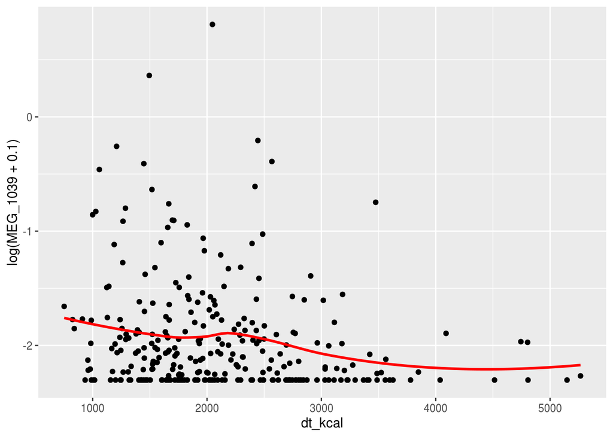

```r
df <- as.data.frame(unclass(sample_data(ps.gene.filtered)))
df$MEG_1039 <- as.numeric(otu_table(ps.gene.filtered)["MEG_1039",])
p <- ggplot(df, aes(x = dt_kcal, y = log(MEG_1039 + 0.1))) + geom_point() +
    geom_smooth(se = F, color = "red")
p
```

Plot of MEG_1488 by dt_fibe, mechanism level

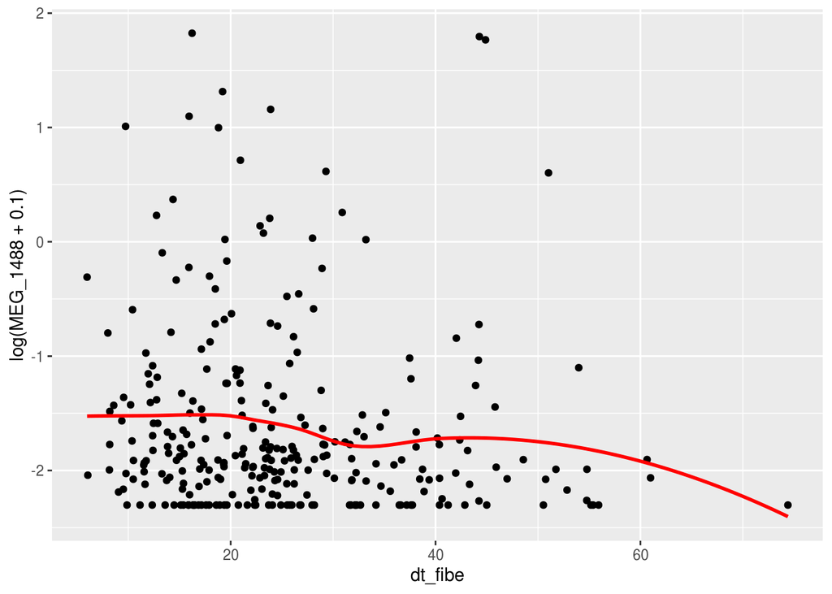

```r
df <- as.data.frame(unclass(sample_data(ps.mechanism.filtered)))
df$MEG_1488 <- as.numeric(otu_table(ps.mechanism.filtered)["MEG_1488",])
p <- ggplot(df, aes(x = dt_fibe, y = log(MEG_1488 + 0.1))) + geom_point() +
    geom_smooth(se = F, color = "red")
p
```

Plot of MEG_1488 by dt_fiber_sol, mechanism level

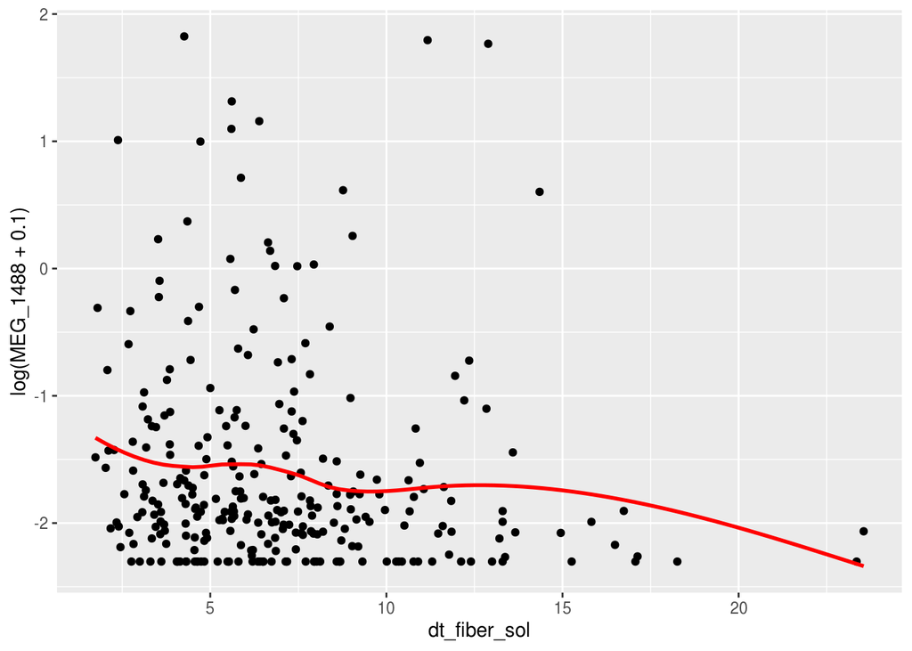

```r
df <- as.data.frame(unclass(sample_data(ps.mechanism.filtered)))
df$MEG_1488 <- as.numeric(otu_table(ps.mechanism.filtered)["MEG_1488",])
p <- ggplot(df, aes(x = dt_fiber_sol, y = log(MEG_1488 + 0.1))) + geom_point() +
    geom_smooth(se = F, color = "red")
p
```

Plot of MEG_1039 by dt_fiber_sol, gene level

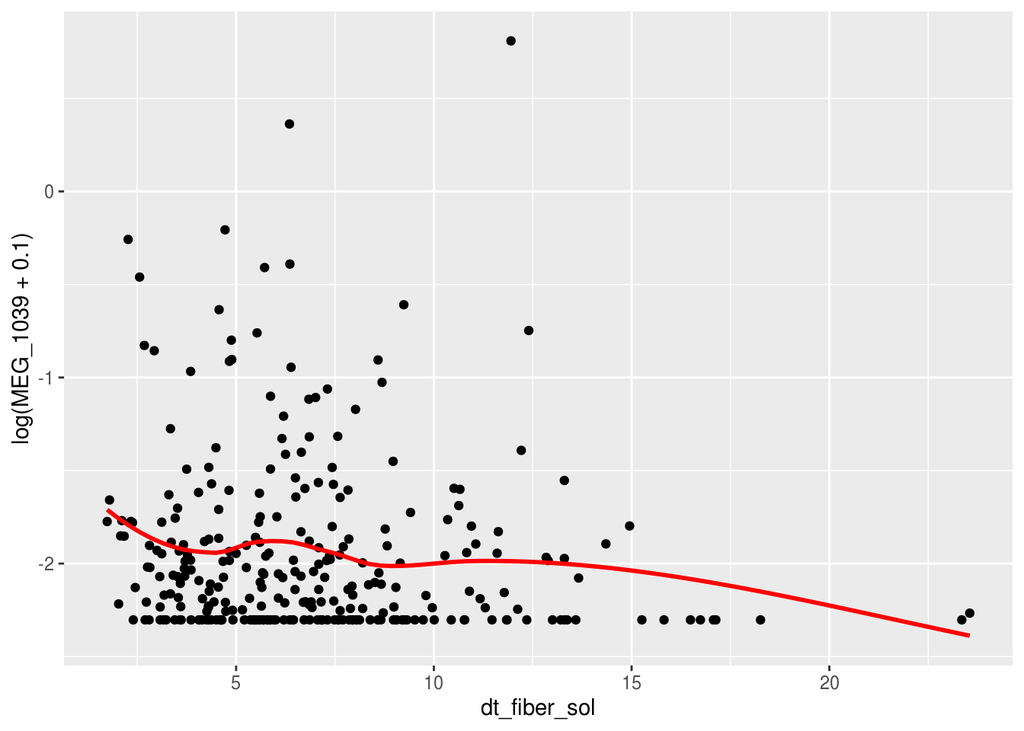

```r
df <- as.data.frame(unclass(sample_data(ps.gene.filtered)))
df$MEG_1039 <- as.numeric(otu_table(ps.gene.filtered)["MEG_1039",])
p <- ggplot(df, aes(x = dt_fiber_sol, y = log(MEG_1039 + 0.1))) + geom_point() +
    geom_smooth(se = F, color = "red")
p
```

Plot of MEG_1488 by dt_fiber_sol, gene level

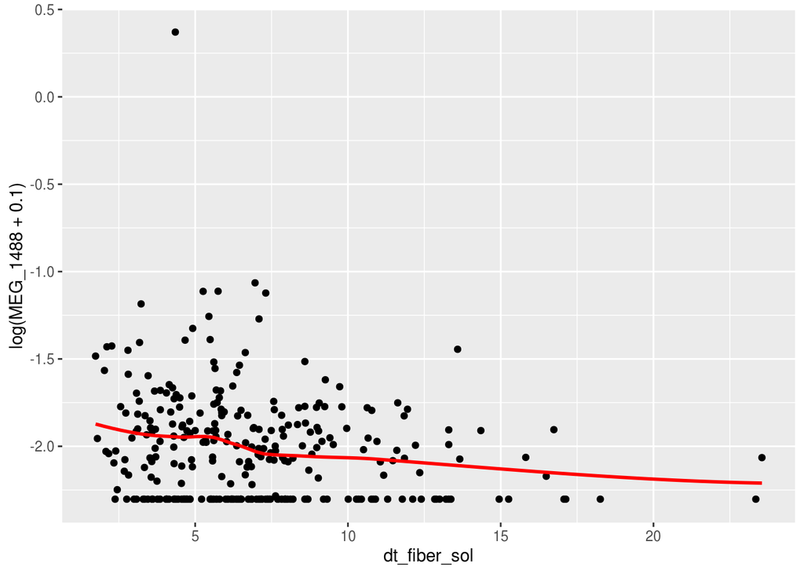

```r
df <- as.data.frame(unclass(sample_data(ps.gene.filtered)))
df$MEG_1488 <- as.numeric(otu_table(ps.gene.filtered)["MEG_1488",])
p <- ggplot(df, aes(x = dt_fiber_sol, y = log(MEG_1488 + 0.1))) + geom_point() +
    geom_smooth(se = F, color = "red")
p
```

Plot of MEG_6093 by ethnicity, mechanism level

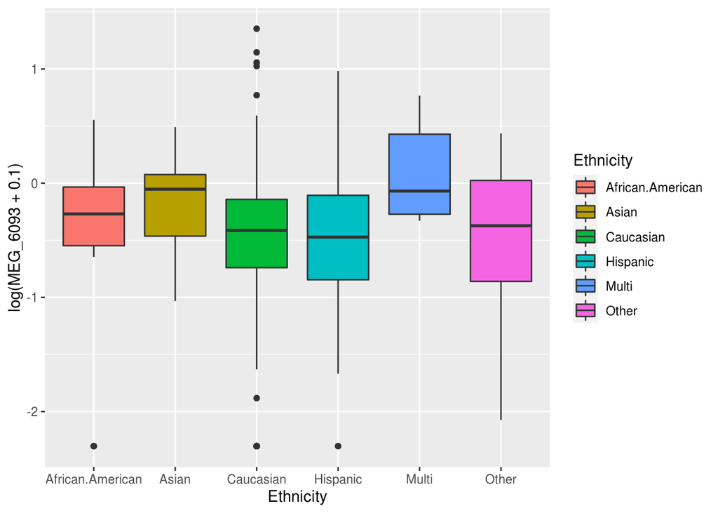

```r
df <- as.data.frame(unclass(sample_data(ps.mechanism.filtered)))
df$MEG_6093 <- as.numeric(otu_table(ps.mechanism.filtered)["MEG_6093",])
p <- ggplot(df, aes(x = Ethnicity, y = log(MEG_6093 + 0.1), fill = Ethnicity)) +
    geom_boxplot()
p
```

Plot of MEG_3295 by ethnicity, mechanism level

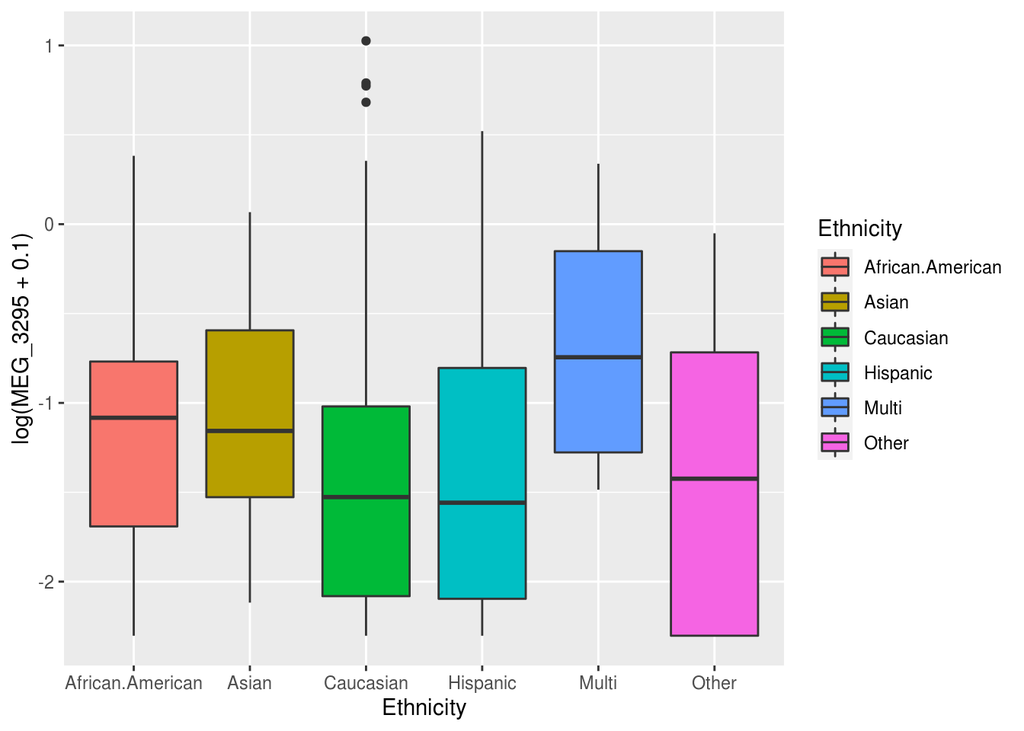

```r
df <- as.data.frame(unclass(sample_data(ps.mechanism.filtered)))
df$MEG_3295 <- as.numeric(otu_table(ps.mechanism.filtered)["MEG_3295",])
p <- ggplot(df, aes(x = Ethnicity, y = log(MEG_3295 + 0.1), fill = Ethnicity)) +
    geom_boxplot()
p
```